# Python Basics I

Date: 22.03.2022  
Lecturers: Harald Kristen & Matthias Wecht

## **Basic Data Types**

Let's talk about the basic data types in Python, below you can find a good overview.A data type is a characteristic that tells the Interpreter (or compiler) how a programmer intends to use the data.

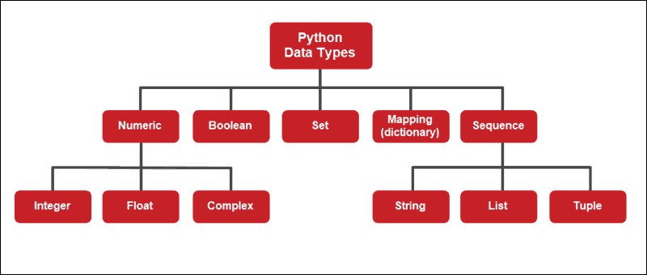

Source: https://phoenixnap.com/kb/wp-content/uploads/2021/04/Python-Data-Types-Overview.png

### Numeric types

Numeric type objects represent number values. They are divided into three subgroups: Integers, Floating Point Numbers, Complex Numbers

**Integer** values belong to the int class. Specifically, integers represent positive or negative whole numbers without a decimal

```python
# Integers (int)
265
```

```
265
```

**Floating-point numbers** in Python are numbers defined with a decimal point. The class type is float.

```python
# Floating point numbers (float)
235.45
```

```
235.45
```

**Complex numbers** are often used in mathematical sciences. Python provides a class for complex numbers called complex

```python
# Complex numbers (complex)
2 + 4j
```

```
(2+4j)
```

**Integers** have *unlimited precision*. There is no distinction between long and short numbers. The length depends on the computer memory.

```python
print(1, "is", type(1))
print(-1, "is", type(-1))
print(99, "is", type(99))
print(-99, "is", type(-99))
print(1234567890, "is", type(1234567890))
print(-1234567890, "is", type(-1234567890))
```

```
1 is <class 'int'>
-1 is <class 'int'>
99 is <class 'int'>
-99 is <class 'int'>
1234567890 is <class 'int'>
-1234567890 is <class 'int'>
```

**Floating-point numbers** after 1.79×10308 evaluate to infinity. The smallest non-zero number is 5.0×10-324. Smaller numbers evaluate to zero:

```python
print(0.1, "is", type(0.1))
print(-1.0, "is", type(-1.0))
print(10., "is", type(10.))
print(123.4567890, "is", type(123.4567890))
```

```
0.1 is <class 'float'>
-1.0 is <class 'float'>
10.0 is <class 'float'>
123.456789 is <class 'float'>
```

```python
print(1.78e308, "is very large")
print(1.80e308, "is infinity")
print(5e-324, "is very small")
print(1e-324, "is zero")
```

```
1.78e+308 is very large
inf is infinity
5e-324 is very small
0.0 is zero
```

### Boolean

**Boolean** only take the values True or False. The boolean value false corresponds to the numeric value 0. Empty strings, lists, tuples and dictionaries are assigned False.

```python
# Boolean (bool)
True, False
```

```
(True, False)
```

```python
print(type(True))
print(type(False))
print(True == 0)
print(False == 1)
```

```
<class 'bool'>
<class 'bool'>
False
False
```

### Set

**Sets** are used to store multiple items in a single variable. A set is a collection which is *unordered, unchangeable, and un-indexed* and cannot have two items with the same value.

```python
myset = {"apple", "banana", "cherry"}
print(myset)
print(type(myset))
```

```
{'cherry', 'apple', 'banana'}
<class 'set'>
```

### Dictionaries

**Dictionaries** are used to store data values in key:value pairs. As of Python version 3.7, dictionaries are ordered.

The key and value pairs accept any data type. To access a value in a dictionary, use the key as index:

```python
thisdict =    {
  "brand": "Ford",
  "model": "Mustang",
  "year": 1964
}
```

```python
print(thisdict)
print("The model is:", thisdict["model"])
```

```
{'brand': 'Ford', 'model': 'Mustang', 'year': 1964}
The model is: Mustang
```

```python
len(thisdict)
```

```
3
```

### Sequences

There are three main sequences in Python that we’ll need in the scope of this course

- **Strings** - unchanging sequences of text data
- **Lists** - changeable sequences of data
- **Tuples** - unchanging sequences of data

#### Strings

- **Strings** are text values that represent non-numeric data
- Elements are characters written inside double " or single ' quotes.
- A special case are the triple ("""or ''') quotes, which allow multiline strings.
- Within the string, each element (character) can be addressed with its index. The numbering starts at 0.
- Strings are immutable.

```python
"Hello World!"
```

```
'Hello World!'
```

```python
"5 + 2"
```

```
'5 + 2'
```

```python
"Hello" + " world!"
```

```
'Hello world!'
```

```python
"Hello" == "Hello!"
```

```
False
```

```python
# check alphabetical order
"Jean" > "Albin"
```

```
True
```

```python
3 == "3"
```

```
False
```

#### Lists

Up to now, everything could be done with a good calculator... now things will get better.

- A list represents an ordered set of values. -Each value can be addressed with an index.
- Lists are surrounded by square brackets and the elements are separated by c commas.
- The values that make up the list are called its elements.
- A list can contain elements of different data types.
- A list is mutable.

```python
my_first_list = ['hello', 1000 , 'world!!    !! ']
```

```python
print(my_first_list)
```

```
['hello', 1000, 'world!!    !! ']
```

```python
my_first_list[0]
```

```
'hello'
```

```python
my_list_1 = [1, 2, 3.5, 'EGM22', True]
my_list_2 = []
my_list_3 = [None]*4
my_list_4 = [None, None, None, None]
my_list_5 = list(range(1,5))
my_list_6 = list(range(0,10,2))
list_of_lists = [my_list_6, my_list_2]

print(my_list_1)
print(my_list_2)
print(my_list_3)
print(my_list_4)
print(my_list_5)
print(my_list_6)
print(list_of_lists)
```

```
[1, 2, 3.5, 'EGM22', True]
[]
[None, None, None, None]
[None, None, None, None]
[1, 2, 3, 4]
[0, 2, 4, 6, 8]
[[0, 2, 4, 6, 8], []]
```

#### Tuples

Tuples are used to store multiple items in a single variable. A tuple is a collection which is ordered and unchangeable.

```python
tuple1 = ("apple", "banana", "cherry")
tuple2 = (1, 5, 7, 9, 3)
tuple3 = (True, False, False)

print(tuple1)
print(tuple2)
print(tuple3)
```

```
('apple', 'banana', 'cherry')
(1, 5, 7, 9, 3)
(True, False, False)
```

#### Summary built-in data types

- **List** is a collection which is ordered and changeable. Allows duplicate members.
- **Tuple** is a collection which is ordered and unchangeable. Allows duplicate members.
- **Set** is a collection which is unordered, unchangeable*, and unindexed. No duplicate members.
- **Dictionary** is a collection which is ordered (>Pyhton 3.7) and changeable. No duplicate members.

## Variables

A variable in the most general sense is simply a container object for holding certain values, for example:

- Numbers
- Strings

Python has a dynamic type system.

- The data type of variables in Python is not set until runtime(compilation) and can be changed during program execution.
- A variable is given a memory address only after it is first assigned a value, and the data type is derived from the assigned value.

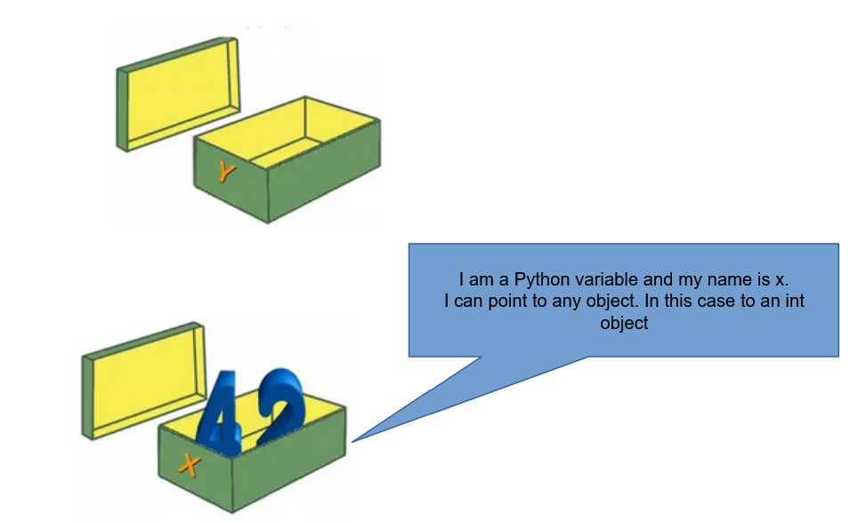

```python
a = 23
b = 7.89
type(a), type(b)
```

```
(int, float)
```

```python
23 + 7.89
```

```
30.89
```

```python
a + b
```

```
30.89
```

```python
print(float(30))
```

```
30.0
```

```python
#del float
```

[output not shown]

```python
string_variable = "Hello world!"
print(string_variable)
type(string_variable)
```

```
Hello world!
```

```
str
```

```python
a = [23 , 'string']
```

```python
print(a)
```

```
[23, 'string']
```

```python
x=32
print(x)
y=x
print(x,y)

y=76
print(x,y)

x='string'
print(x,y)
```

```
32
32 32
32 76
string 76
```

```python
a, b, c = 1, 2, 3
print(a, b, c)

a = b = c = 2
print(a, b, c)

z = [a, b] = [4, 5]
print(a, b, z)
```

```
1 2 3
2 2 2
4 5 [4, 5]
```

```python
a
```

```
4
```

```python
b
```

```
5
```

```python
[a , 1 , b]
```

```
[4, 1, 5]
```

**Variable names** can be..

- of any length.
- letters (A to Z and a to z).
- digits (0 to 9), (not in first position!)
- and contain the underscore _ parameter.

**Attention**:

- Upper/lower case does matter!
- No keywords allowed as variable names!
- No special characters (except underscore character "_")

See [selecting “good” variable names](https://geo-python.github.io/site/notebooks/L1/gcp-1-variable-naming.html#Good-coding-practices---Selecting-) for naming guidelines

```python
import keyword
keyword.kwlist
```

```
['False',
 'None',
 'True',
 'and',
 'as',
 'assert',
 'async',
 'await',
 'break',
 'class',
 'continue',
 'def',
 'del',
 'elif',
 'else',
 'except',
 'finally',
 'for',
 'from',
 'global',
 'if',
 'import',
 'in',
 'is',
 'lambda',
 'nonlocal',
 'not',
 'or',
 'pass',
 'raise',
 'return',
 'try',
 'while',
 'with',
 'yield']
```

## Operators

### Arithmetic Operations

All arithmetic operators:

- +, -, *, /
- %, **, //

```python
a = 4
b = 7
##addition
print(a+b)
##substraction
print(a-b)
##multiplication
print(a*b)
##divison
print(a/b)
##potentiate
print(a**b)
##negative prefix
print(-a)
##modulo
print(a%b)
```

```
11
-3
28
0.5714285714285714
16384
-4
4
```

```python
x = 5.3
```

```python
4 * 3.0
```

```
12.0
```

```python
int(x)
```

```
5
```

```python
# // -> Floor division
13//2
```

```
6
```

```python
# ** -> exponent
3**3
```

```
27
```

```python
# operators precedence
print( 2*2**2 )
print( (2*2)**2 )
```

```
8
16
```

**Assignment operators** are used to assign values to variables.

More examples: [Operators](https://www.w3schools.com/python/python_operators.asp)

```python
x=5

x += 3
print(x)
x -= 3
print(x)
x *= 3
print(x)
x /= 3
print(x)
x %= 3
print(x)
```

```
8
5
15
5.0
2.0
```

```python
x = x + 3
x
```

```
5.0
```

```python
x
```

```
5.0
```

**Note:** Don't use square brackets [ ].or curly brackets to write expressions

### Comparison Operators

Are used to compare two values:

**==, !=, >, <, >=, <=**

```python
# the result is always a boolean
2 == 3
```

```
False
```

```python
1>2
```

```
False
```

```python
int(True)
```

```
1
```

```python
float(2)
```

```
2.0
```

```python
123 >= 123.1
```

```
False
```

```python
# comparing two objects
123 == "123", 123 != "123"
```

```
(False, True)
```

```python
int("234")
```

```
234
```

```python
# Remove int to raise error
123 <= int("234")
```

```
True
```

```python
a = 5
b = 3

print(a==b)
print(a!=b)
print(a>b)
print(a<b)
print(a>=b)
print(a<=b)
```

```
False
True
True
False
True
False
```

### Logical Operators

Always compare booleans  
**and, or, not**

```python
not False
```

```
True
```

```python
2 < 5 and (3 < 4)
```

```
True
```

```python
not (2 > 5) or (3 < 4)
```

```
True
```

**Logical operators** are also used to combine conditional statements.

```python
a = 5

print(a < 2 and a > 2)
print(a > 10 or a < 6)
print(not(a > 10))
```

```
False
True
True
```

```python
a = 5
b = 7

print(a & b > 2)
print(a | b > 5)
print(a ^ b > 5)
```

```
True
True
False
```

## Basic methods

### String methods

Powerful built-in methods to work with strings see [Python Docs: String methods](https://docs.python.org/3/library/stdtypes.html#string-methods)

```python
s = 'Hello, World!'
```

```python
s.replace('Hello', 'Hi')
```

```
'Hi, World!'
```

```python
s.lower()
```

```
'hello, world!'
```

```python
s.swapcase()
```

```
'hELLO, wORLD!'
```

```python
'234'.isnumeric()
```

```
True
```

```python
s
```

```
'Hello, World!'
```

```python
s.find('World')
```

```
7
```

```python
s.isnumeric()
```

```
False
```

```python
# Split
s = 'Hello, World!'
print(s)
s_split = s.split('l')
print(s_split)


# Join
print(''.join(['1', '2', '3']))
print('-'.join(['1', '2', '3']))


# Find
s.split()
```

```
Hello, World!
['He', '', 'o, Wor', 'd!']
123
1-2-3
```

```
['Hello,', 'World!']
```

### List methods

List are a essential Python data type that you will need all the time. So let's have a look what we can do with them.

More powerful built-in methods to work with lists see [Python Docs: List methods](https://docs.python.org/3/tutorial/datastructures.html)

```python
a = [1, 2, 3]
b = [4, 5, 6]
c = a + b
print (c)
print([0] * 4)
print([1, 2, 3] * 3)
print([None]*5)
```

```
[1, 2, 3, 4, 5, 6]
[0, 0, 0, 0]
[1, 2, 3, 1, 2, 3, 1, 2, 3]
[None, None, None, None, None]
```

List elements can be accessed with numeric indices

```python
list_bsp = ['a', 'b', 'c', 'd', 'e', 'f']

print(list_bsp[1:3])
print(list_bsp[:4])
print(list_bsp[3:])
print(list_bsp[:])
print(list_bsp[-1])
print(list_bsp[-1:])
```

```
['b', 'c']
['a', 'b', 'c', 'd']
['d', 'e', 'f']
['a', 'b', 'c', 'd', 'e', 'f']
f
['f']
```

List elements can be deleted with indices.

```python
a = ['one', 'two', 'three']
del a[1]
print(a)

my_list = ['a', 'b', 'c', 'd', 'e', 'f']
del my_list[1:5]
print (my_list)
```

```
['one', 'three']
['a', 'f']
```

```python
x_liste= [1, 2, 3]
y_liste= x_liste
y_liste[0] = 42 # Attention!!!
print(x_liste, y_liste)
```

```
[42, 2, 3] [42, 2, 3]
```

```python
x_liste= [1, 2, 3]
y_liste= x_liste.copy()
y_liste[0] = 42
print(x_liste, y_liste)
```

```
[1, 2, 3] [42, 2, 3]
```

## How to find help :)

### How to google for errors?

The usual way is to copy the error message and type it in google. Often Stackoverflow will pop up - it is a rich resource/forum for all kind of computer related questions. Especially the Python & Geo community is well represented there

-> search for the tag 'geo' here https://stackoverflow.com/tags

```python
1 + 'standard'
```

```
---------------------------------------------------------------------------
TypeError                                 Traceback (most recent call last)
Cell In[79], line 1
----> 1 1 + 'standard'

TypeError: unsupported operand type(s) for +: 'int' and 'str'
```

```python
str(1) + 'standard'
```

```
'1standard'
```

```python
5 +! 2
```

```
  Cell In[81], line 1
    5 +! 2
       ^
SyntaxError: invalid syntax
```

```python
stri(1)
```

```
---------------------------------------------------------------------------
NameError                                 Traceback (most recent call last)
Cell In[82], line 1
----> 1 stri(1)

NameError: name 'stri' is not defined
```

### AI Tools like ChatGPT for Python Help

AI tools like ChatGPT can be valuable for quick problem-solving and learning. However, they should be used with caution alongside other resources to enhance your Python journey.

### How to Access ChatGPT

You can access ChatGPT through its [web app](https://chat.openai.com/). The base model GPT3.5 is currently free to use, this might change in the future. Ofc there are a multitude of other emerging AI tools to help with coding such as [Github CoPilot](https://github.com/features/copilot) but first you need to understand the basic concepts of Python, to actually use such tools in a meaningful manner.

### Limitations to to be aware of

While ChatGPT is a powerful tool, it's important to be aware of its limitations:

1. **Hallucinations:** ChatGPT might generate responses that appear plausible but are incorrect or nonsensical. Always critically evaluate the information.
2. **Knowledge Cutoff:** The model's knowledge is based on information available up to January 2022. Ensure you verify information for the latest updates.
3. **Not a Substitute for Learning:** While ChatGPT can provide helpful insights, it's not a substitute for understanding fundamental concepts. Use it as a supplementary tool for learning.

### Best Practices

When seeking help from AI tools like ChatGPT:

- **Be Specific:** Clearly articulate your question or problem to get more accurate responses.
- **Verify Information:** Double-check information received from ChatGPT to ensure accuracy.
- **Explore Other Resources:** Don't rely solely on AI tools. Explore documentation, forums, and other learning materials for a comprehensive understanding.

### Steps to Use ChatGPT for Error Resolution

When encountering errors in the Python console, leverage ChatGPT efficiently with these five tips:

1. **Precise Querying:** Clearly state the error message and provide context. Specify the problematic code or describe the issue concisely.
2. **Interpretation Assistance:** If the error message is unclear, ask ChatGPT for an explanation. Seek help in understanding what the error signifies.
3. **Alternative Solutions:** Inquire about alternative approaches to solve the problem. ChatGPT can suggest different coding strategies or point out potential improvements.
4. **Learning Resources:** Request recommendations for learning resources related to the error. ChatGPT can suggest documentation, tutorials, or specific topics to deepen your understanding.
5. **Verification:** After receiving suggestions, verify the information. Cross-reference with official documentation and community forums to ensure accuracy and gain a comprehensive understanding.

# License Information

This notbook is based on https://github.com/cordmaur/PythonForScientists -> see [LICENSE File](https://github.com/cordmaur/PythonForScientists/blob/main/LICENSE) for license information